# Descriptives

Note!! This document contains custom functions and plot objects, declared at the top.

## Table of contents

- Import data
- Sample analysis
- Manipulation checks
- Task conscientiousness
- CS attitudes
- Persistence as a measure of interest
- Possible alternative explanations
- Common-sense correlations between constructs

## Import data

(Hidden)

Note: Try making your own ggplot themes

Customize functions (hidden)

Custom functions (hidden)

[Source](https://stackoverflow.com/questions/20637360/convert-all-data-frame-character-columns-to-factors/20637986)

```r
dat[sapply(dat, is.factor)] <- lapply(dat[sapply(dat, is.factor)],
                                      as.numeric)
```

Statistics notes: * [source](http://www.sthda.com/english/wiki/correlation-test-between-two-variables-in-r) use Shapiro Wilk to check normality, then test for significant correlation

## Sample analysis

Plot majors (split responses so that students reporting multiple majors are counted multiple times). First plot shows results from presurvey; second shows those who actually took the main study.

Note: how to deal with students reporting multiple majors in the main analyses?

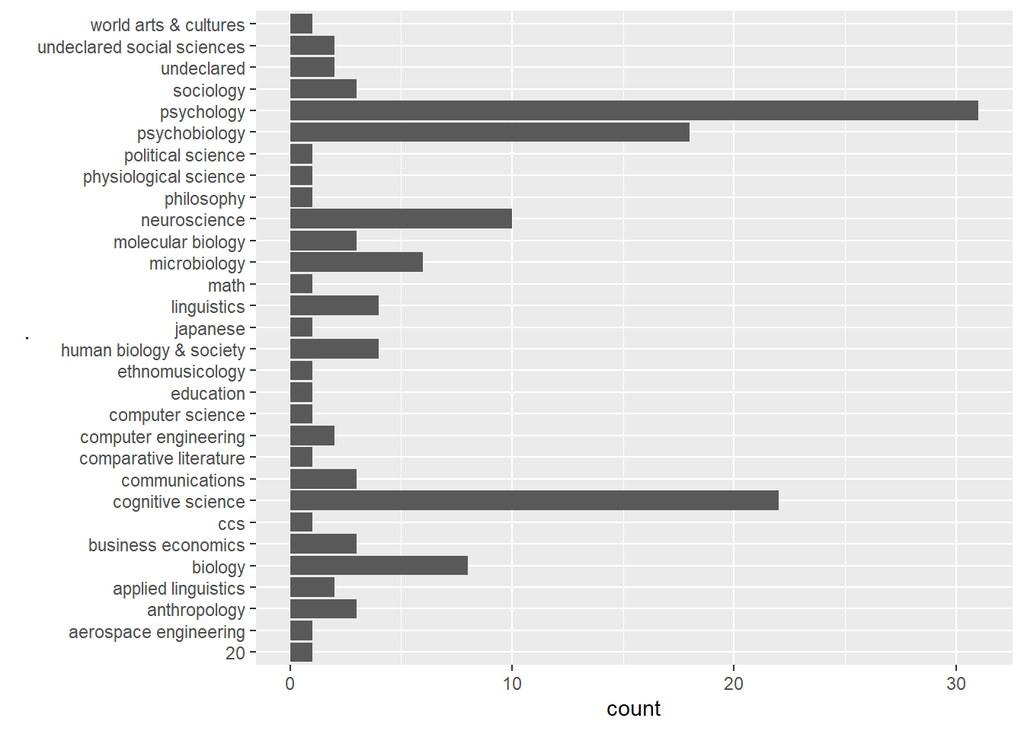

```r
# Pre-survey
str_split(pre$major_txt, " and |, | or ") %>%
  unlist() %>%
  data.frame() %>%
  ggplot(aes(.)) +
  geom_bar() +
  coord_flip()
```

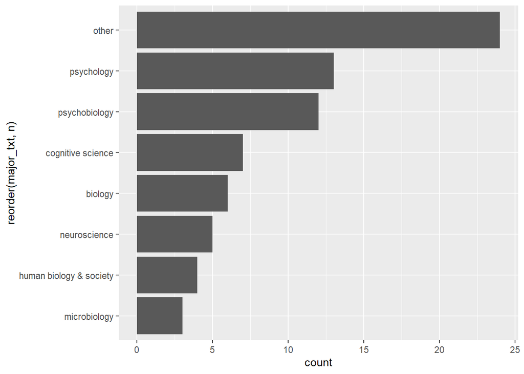

```r
# Main survey
dat %>%
  group_by(major_txt) %>%
  mutate(n = n()) %>%
  ungroup() %>%
  ggplot(aes(reorder(major_txt, n))) +
  geom_bar() +
  coord_flip()
```

Examine race and gender distribution of survey participants. Note: I only started saving this information halfway through the study. I assume that the second half of students are similar to the first. For some values, such as gender, I checked the condition and deduced the participant’s gender.

```r
table(dat$p_race)
```

```
##
##  1  2  3  4  5
## 21 14 12  3 24
```

```r
dat %>%
  filter(p_race != "unknown") %>%
  select(p_race) %>%
  table() %>%
  prop.table() %>%
  round(3)
```

```
## .
##     1     2     3     4     5
## 0.284 0.189 0.162 0.041 0.324
```

```r
table(dat$p_gender)
```

```
##
##  1  2
## 21 53
```

```r
facttab(dat$p_gender)
```

```
## .
##     1     2
## 0.284 0.716
```

I will check the presurvey to see if those demographics are somewhat consistent with those gained from the latter half of the main study.

```r
table(pre$race)
```

```
##
##                       White Non-white Hispanic (Latino)
##                          32                          32
##   Asian or Pacific Islander   Black or African American
##                          64                           4
```

```r
facttab(pre$race)
```

```
## .
##                       White Non-white Hispanic (Latino)
##                       0.242                       0.242
##   Asian or Pacific Islander   Black or African American
##                       0.485                       0.030
```

Comparing the tables, it looks like there could not have been more than 1 Black participant whose race was later marked “unknown”, and there are comparable percentages of known white, Latino, and Asian participants between the presurvey and the main study.

The UCLA admissions [demographics page](https://admission.ucla.edu/apply/student-profile) (accessed Dec. 2021) shows that for admitted freshmen, 3% are Black, 33% are Asian or Pacific Islander, 21% are Hispanic, and 25% are white. Thus, we obtained an approximately representative sample of UCLA students.

```r
table(pre$gender)
```

```
##
## Female   Male
##     98     34
```

```r
facttab(pre$gender)
```

```
## .
## Female   Male
##  0.742  0.258
```

We then analyze distributions of age, employment, transfer status, and year:

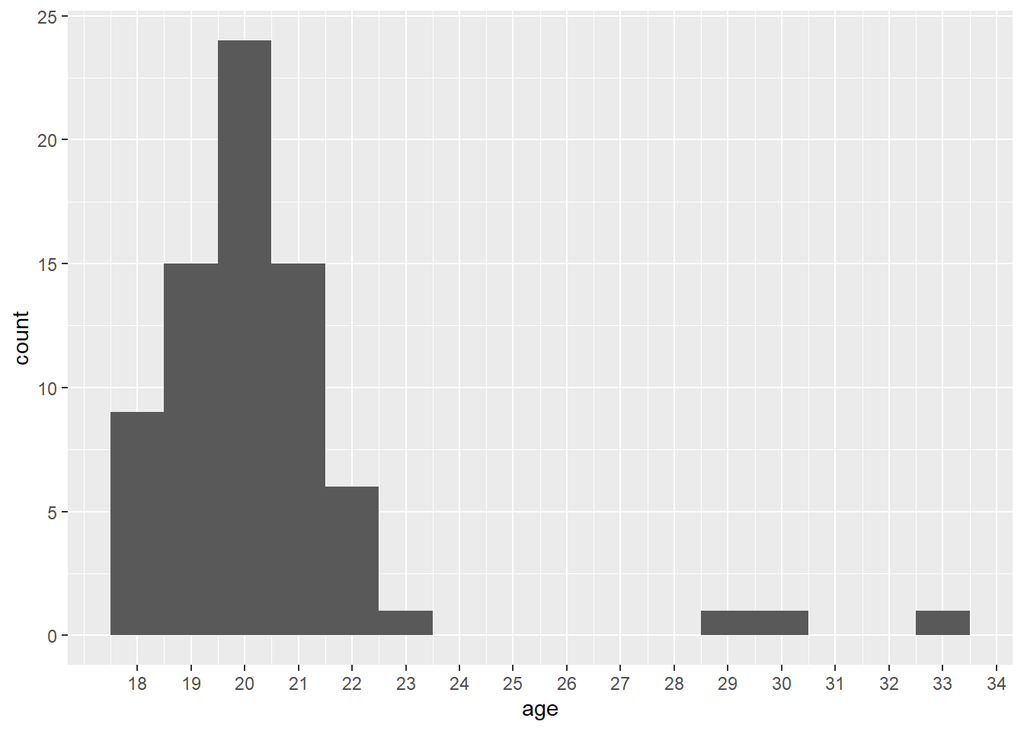

```r
ggplot(aes(age), data = dat) +
  geom_histogram(binwidth=1) +
  scale_x_continuous(breaks = c(18:34))
```

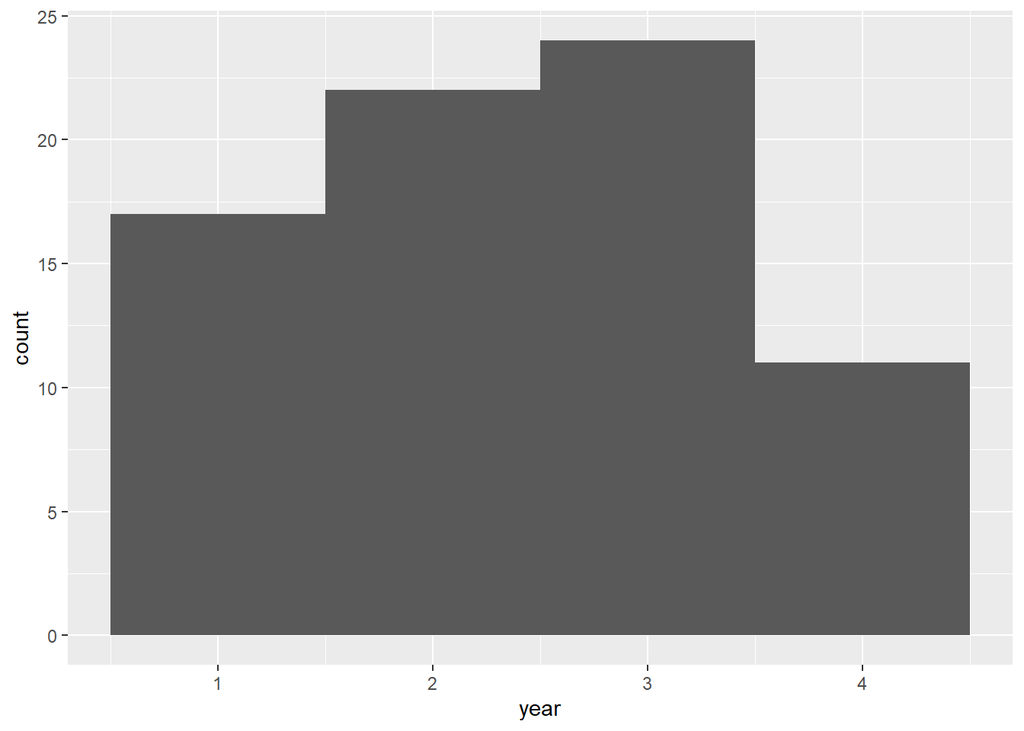

```r
ggplot(aes(year), data = dat) +
  geom_histogram(binwidth=1)
```

This study was conducted in Spring 2021. The sample is slightly overrepresentative of second- and third-years.

```r
facttab(dat$employ2)
```

```
## .
##     0     1     2     3     4     5
## 0.689 0.108 0.095 0.054 0.027 0.027
```

I think it’s incredibly unlikely that well over 50% of the students at UCLA don’t have paid employment. I can’t find a source stating how many students usually work.

```r
facttab(dat$transfer)
```

```
## .
##    1    2
## 0.77 0.23
```

UCLA [campus statistics](https://apb.ucla.edu/campus-statistics/enrollment) states that UCLA’s total transfer population is 30.8%.

## Manipulation checks

Did people honestly report whether they switched or not?

```r
dat %>%
  filter(switched==0 & persist < 7) %>%
  select(id)
```

```
##       id
## 1 171313
```

Only one participant misreported not switching when they did not last all 7 parts, which is good.

How much did the model manipulation checks correlate with each other?

```r
dat %>%
  select(matches("model"), -model_gender, -model_race, -model_txt, -model_score) %>%
  cormat()
```

```
##                model_similar model_respect model_friendly model_like
## model_similar          1.000            NA             NA         NA
## model_respect          0.305         1.000             NA         NA
## model_friendly         0.353         0.802          1.000         NA
## model_like             0.422         0.808          0.837          1
```

It seems that the `respect`, `friendly`, and `like` measures all correlate very well, so we can try to use the composite score as a measure of general feeling of warmth for the role model.

Did people generally feel similar to the role model? The average is 3.1486486.

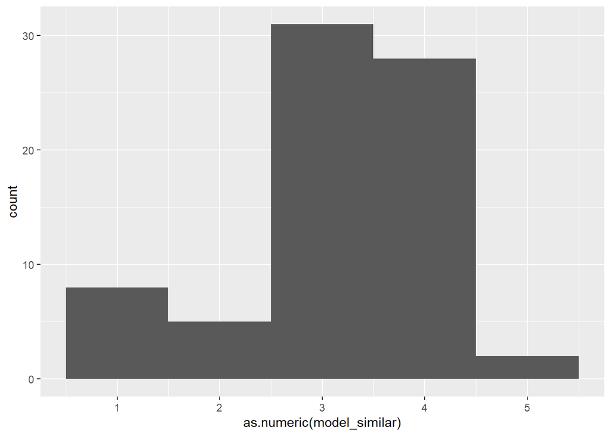

```r
dat %>%
  ggplot(aes(as.numeric(model_similar))) +
  geom_histogram(binwidth=1)
```

Plot the race and gender of role models against their composite rating. (There is only 1 model in each intersectional category.)

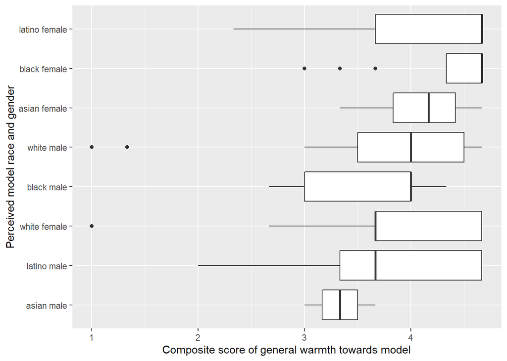

```r
dat %>%
  group_by(img) %>%
  mutate(med = median(model_score)) %>%
  ungroup() %>%
  ggplot(aes(model_score, reorder(img, med))) +
  geom_boxplot() +
  xlab("Composite score of general warmth towards model") +
  ylab("Perceived model race and gender")
```

Does participant-model similarity correlate with perception of self-model similarity?

```r
dat %>%
  select(model_similar,
         post_belonging,
         dr,
         dg) %>%
  cormat()
```

```
##                model_similar post_belonging    dr dg
## model_similar          1.000             NA    NA NA
## post_belonging         0.293          1.000    NA NA
## dr                    -0.132         -0.048 1.000 NA
## dg                    -0.202          0.196 0.001  1
```

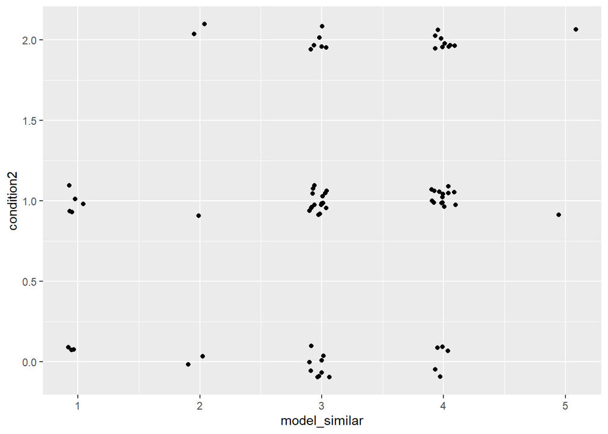

```r
dat %>%
  ggplot(aes(model_similar, condition2)) +
  jitter
```

Perceived similarity does not correlate with actual condition, or with sense of belonging in CS.

## Task conscientiousness

I worry that since we don’t check for accurate work, students spent very little time on the exercises and didn’t actually complete them conscientiously. From graphing everyone’s results, it doesn’t appear that there is a clear cutoff for those who are conscientiously doing the exercises and those who are not. Maybe 7 minutes? But at that point, users who gave more than 7 minutes per page seem almost to be outliers.

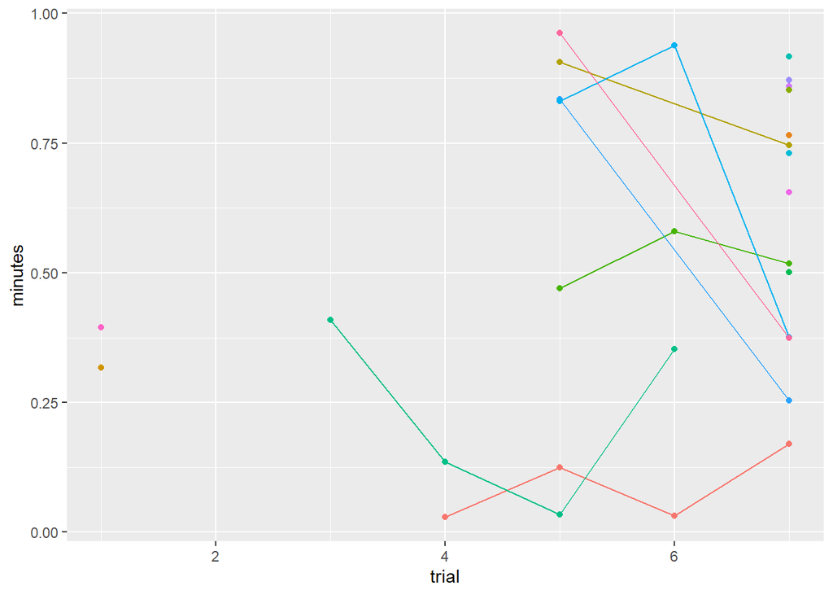

```r
dat %>%
  select(matches("time_\\d"), id) %>%
  pivot_longer(matches("time"), names_to="time", values_to="seconds") %>%
  mutate(trial = as.numeric(substr(time, nchar(time), nchar(time))),
         minutes = seconds/60) %>%
  filter(minutes < 1) %>%
  ggplot(aes(trial, minutes, color=id)) +
  geom_path() +
  geom_point() +
  theme(legend.position = "none")
```

Sure enough, there are many instances where people spent less than 1 minute on the page, which is quite impossible as each page asks you to read, and also to complete the exercise. There seems to be an increase of these instances towards the later pages, which means that we could look into recoding these responses as persisting for 1 trial less than they did. I should at least filter out responses that spent less than 1 minute on trial 1. (Note: implemented this in the cleaning doc.)

How long did people spend on tasks on average? There appears to be an outlier where someone in trial 3 spent 4 hours, which I take to mean that they left their program running and came back to finish the activity later. I will remove them from the analysis.

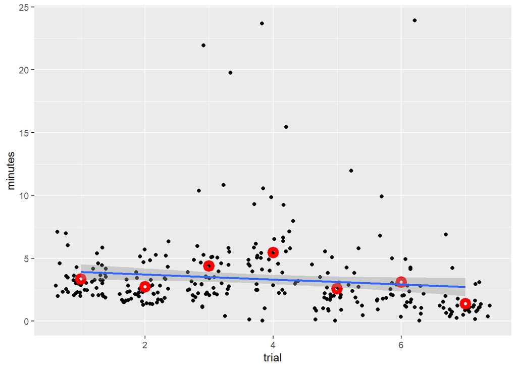

```r
dat %>%
  filter(time_3 < 10000) %>%
  select(matches("time_\\d")) %>%
  pivot_longer(matches("time"), names_to="time", values_to="seconds") %>%
  mutate(trial=as.numeric(substr(time, nchar(time), nchar(time))),
         minutes=seconds/60) %>%
  group_by(trial) %>%
  mutate(mean_time = mean(minutes, na.rm=TRUE)) %>%
  ungroup() %>%
  ggplot(aes(trial, minutes)) +
  geom_jitter() +
  geom_point(aes(trial, mean_time), color="red", stroke=3, shape=1) +
  stat_smooth(method="lm")
```

## CS Attitudes

Note: using definition of strong correlation as 0.7 from [West GA](https://www.westga.edu/academics/research/vrc/assets/docs/scatterplots_and_correlation_notes.pdf) (page 9)

Distributions for pre-activity attitudes.

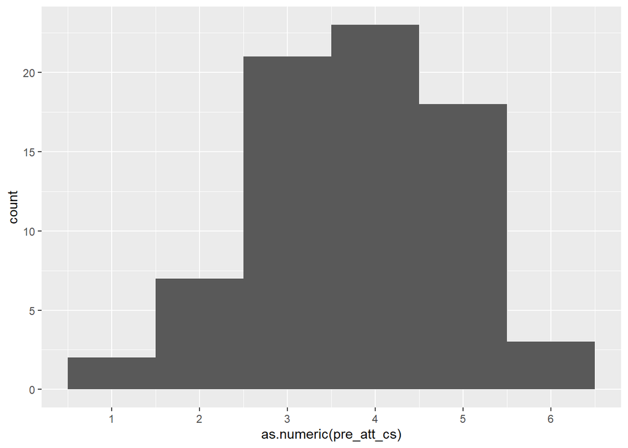

```r
dat %>%
  ggplot(aes(as.numeric(pre_att_cs))) +
  geom_histogram(binwidth=1) +
  scale_x_continuous(breaks=1:7)
```

We reveal that only 2 students reported little to no prior interest in CS. This may be due to acquiescence/demand characteristics, or a characteristic of the subject pool (psychology students).

Do the pre- and post- measures for CS interest capture a similar construct?

```r
dat %>%
  select(matches("act"),
         -matches("txt"),
         -matches("att_")) %>%
  cormat()
```

```
##                   pre_interest_act pre_like_act pre_useful_act pre_relevant_act
## pre_interest_act             1.000           NA             NA               NA
## pre_like_act                 0.909        1.000             NA               NA
## pre_useful_act               0.684        0.683          1.000               NA
## pre_relevant_act             0.563        0.606          0.666            1.000
## pre_conf_act                 0.005        0.079          0.043           -0.038
## post_interest_act            0.487        0.390          0.374            0.276
## post_like_act                0.424        0.337          0.299            0.210
## post_useful_act              0.185        0.157          0.259            0.185
## post_relevant_act            0.165        0.113          0.294            0.262
## post_conf_act                0.153        0.187          0.204            0.063
##                   pre_conf_act post_interest_act post_like_act post_useful_act
## pre_interest_act            NA                NA            NA              NA
## pre_like_act                NA                NA            NA              NA
## pre_useful_act              NA                NA            NA              NA
## pre_relevant_act            NA                NA            NA              NA
## pre_conf_act             1.000                NA            NA              NA
## post_interest_act       -0.127             1.000            NA              NA
## post_like_act           -0.154             0.868         1.000              NA
## post_useful_act         -0.177             0.654         0.611           1.000
## post_relevant_act       -0.028             0.529         0.521           0.662
## post_conf_act            0.570             0.191         0.227           0.197
##                   post_relevant_act post_conf_act
## pre_interest_act                 NA            NA
## pre_like_act                     NA            NA
## pre_useful_act                   NA            NA
## pre_relevant_act                 NA            NA
## pre_conf_act                     NA            NA
## post_interest_act                NA            NA
## post_like_act                    NA            NA
## post_useful_act                  NA            NA
## post_relevant_act             1.000            NA
## post_conf_act                 0.313             1
```

Strangely, usefulness and relevance appear to capture different constructs; they correlate only moderately.

Note: I am now creating a pre/post_att_act variable to capture interest and liking together.

```r
dat %>%
  select(matches("pre.*cs"),
         matches("post.*cs"),
         -matches("txt"),
         -matches("att_")) %>%
  cormat()
```

```
##                  pre_enjoy_cs pre_learn_cs pre_course_cs pre_interest_cs
## pre_enjoy_cs            1.000           NA            NA              NA
## pre_learn_cs            0.699        1.000            NA              NA
## pre_course_cs           0.680        0.719         1.000              NA
## pre_interest_cs         0.639        0.632         0.679           1.000
## pre_excite_cs           0.614        0.637         0.685           0.731
## pre_conf_cs             0.386        0.237         0.238           0.326
## post_interest_cs        0.389        0.354         0.439           0.696
## post_excite_cs          0.475        0.542         0.580           0.640
## post_conf_cs            0.157        0.196         0.229           0.340
##                  pre_excite_cs pre_conf_cs post_interest_cs post_excite_cs
## pre_enjoy_cs                NA          NA               NA             NA
## pre_learn_cs                NA          NA               NA             NA
## pre_course_cs               NA          NA               NA             NA
## pre_interest_cs             NA          NA               NA             NA
## pre_excite_cs            1.000          NA               NA             NA
## pre_conf_cs              0.529       1.000               NA             NA
## post_interest_cs         0.577       0.263            1.000             NA
## post_excite_cs           0.604       0.237            0.792          1.000
## post_conf_cs             0.410       0.509            0.421          0.419
##                  post_conf_cs
## pre_enjoy_cs               NA
## pre_learn_cs               NA
## pre_course_cs              NA
## pre_interest_cs            NA
## pre_excite_cs              NA
## pre_conf_cs                NA
## post_interest_cs           NA
## post_excite_cs             NA
## post_conf_cs                1
```

This is pretty cool. Pre- and post-activity, only interest in taking a formal course and interest in self-learning correlate strongly! Except that interest and excitement correlate well both before and after.

I want to explore whether variation in persistence really does reflect interest in the activity. In order to do so, I want to start out by asking whether the `fit_*` variables correlate sufficiently to create a composite score of CS belongingness. (As a side note, I wonder if the activity affected participants’ answers on these measures, since we didn’t have presurvey measures of CS attitudes.)

These show effects of framing and how people think.

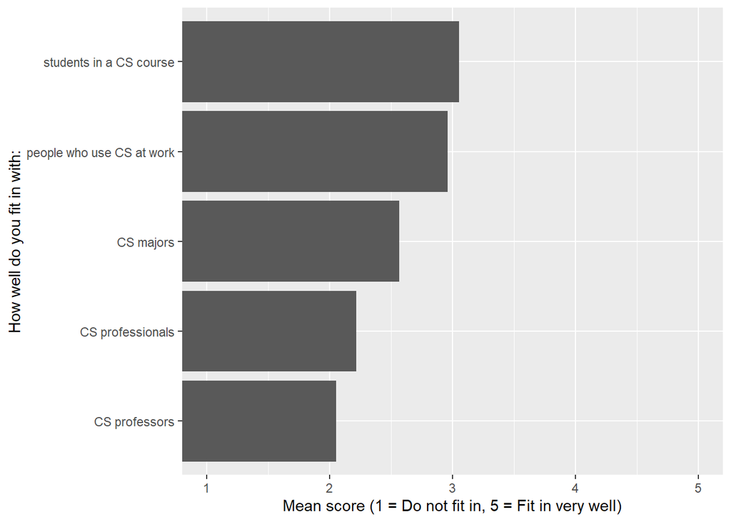

```r
dat %>%
  select(matches("fit"),
         -matches("txt")) %>%
  summarize_all(mean, na.rm = TRUE) %>%
  pivot_longer(matches("fit"), names_to = "fit", values_to = "mean") %>%
  mutate(labs = c("students in a CS course",
                  "CS professionals",
                  "people who use CS at work",
                  "CS professors",
                  "CS majors")) %>%
  ggplot(aes(reorder(labs, mean), mean)) +
  geom_bar(stat="identity") +
  xlab("How well do you fit in with:") +
  ylab("Mean score (1 = Do not fit in, 5 = Fit in very well)") +
  coord_flip(ylim = c(1,5))
```

```r
dat %>%
  select(matches("fit"),
         -matches("txt")) %>%
  cormat()
```

```
##              fit_cs_class fit_cs_job fit_cs_skill fit_cs_teach fit_cs_major
## fit_cs_class        1.000         NA           NA           NA           NA
## fit_cs_job          0.671      1.000           NA           NA           NA
## fit_cs_skill        0.677      0.450        1.000           NA           NA
## fit_cs_teach        0.336      0.603        0.220        1.000           NA
## fit_cs_major        0.651      0.619        0.582        0.557            1
```

Interestingly, these questions seemed to have captured different constructs, with perceived similarity to CS professors the most dissimilar compared with students in those same CS courses. I wonder if this is a reflection of age factors, rather than a reflection of personality traits.

Overall, the trends appear to make sense: being a professional programmer only correlates weakly with having CS as part of your job; fitting in with CS majors correlates moderately with all measures having to do with CS. The professor-fit measure only correlates with CS major fit and job fit, suggesting that students (understandably) associate teaching with expertise. It is likely not due to age difference factors, since students do not associate having a job involving CS skills and teaching CS.

How do utility beliefs (ie relevance and usefulness) affect intent to pursue CS or openness to changing attitude?

```r
dat %>%
  select(matches("relevant"),
         matches("useful"),
         matches("r_att"),
         matches("d_att_"),
         matches("likely"),
         -matches("txt")) %>%
  cormat()
```

```
##                   pre_relevant_act post_relevant_act pre_useful_act
## pre_relevant_act             1.000                NA             NA
## post_relevant_act            0.262             1.000             NA
## pre_useful_act               0.666             0.294          1.000
## post_useful_act              0.185             0.662          0.259
## pre_r_att                    0.215             0.401          0.316
## post_r_att                   0.125             0.459          0.338
## d_att_cs                    -0.011             0.348         -0.078
## d_att_act                   -0.282             0.409         -0.277
## d_att_r                     -0.077             0.059          0.025
## likely_cs_course             0.104             0.540          0.198
## likely_cs_job                0.142             0.529          0.192
## likely_self_learn            0.168             0.361          0.238
##                   post_useful_act pre_r_att post_r_att d_att_cs d_att_act
## pre_relevant_act               NA        NA         NA       NA        NA
## post_relevant_act              NA        NA         NA       NA        NA
## pre_useful_act                 NA        NA         NA       NA        NA
## post_useful_act             1.000        NA         NA       NA        NA
## pre_r_att                   0.383     1.000         NA       NA        NA
## post_r_att                  0.472     0.373      1.000       NA        NA
## d_att_cs                    0.339     0.006      0.387    1.000        NA
## d_att_act                   0.491     0.178      0.411    0.364     1.000
## d_att_r                     0.087    -0.548      0.572    0.343     0.213
## likely_cs_course            0.512     0.502      0.352    0.157     0.344
## likely_cs_job               0.424     0.346      0.245    0.174     0.179
## likely_self_learn           0.229     0.445      0.374    0.087     0.180
##                   d_att_r likely_cs_course likely_cs_job likely_self_learn
## pre_relevant_act       NA               NA            NA                NA
## post_relevant_act      NA               NA            NA                NA
## pre_useful_act         NA               NA            NA                NA
## post_useful_act        NA               NA            NA                NA
## pre_r_att              NA               NA            NA                NA
## post_r_att             NA               NA            NA                NA
## d_att_cs               NA               NA            NA                NA
## d_att_act              NA               NA            NA                NA
## d_att_r             1.000               NA            NA                NA
## likely_cs_course   -0.126            1.000            NA                NA
## likely_cs_job      -0.085            0.694         1.000                NA
## likely_self_learn  -0.056            0.634         0.639                 1
```

```r
dat %>%
  filter(major_txt != "cognitive science") %>%
  select(matches("relevant"),
         matches("likely")) %>%
  cormat()
```

```
##                   pre_relevant_act post_relevant_act likely_cs_course
## pre_relevant_act             1.000                NA               NA
## post_relevant_act            0.241             1.000               NA
## likely_cs_course             0.108             0.586            1.000
## likely_cs_job                0.160             0.599            0.673
## likely_self_learn            0.187             0.386            0.596
##                   likely_cs_job likely_self_learn
## pre_relevant_act             NA                NA
## post_relevant_act            NA                NA
## likely_cs_course             NA                NA
## likely_cs_job             1.000                NA
## likely_self_learn         0.572                 1
```

Results here aren’t too clear. Overall, it appears that post-activity usefulness and relevance attitudes about the activity correlate moderately with likelihood of taking a course in CS, but less for taking a job in CS and even less for learning CS on one’s own. Pre-activity attitudes do not correlate with any of the above.

## Persistence as a measure of interest

Did the study materials yield the expected variation in persistence?

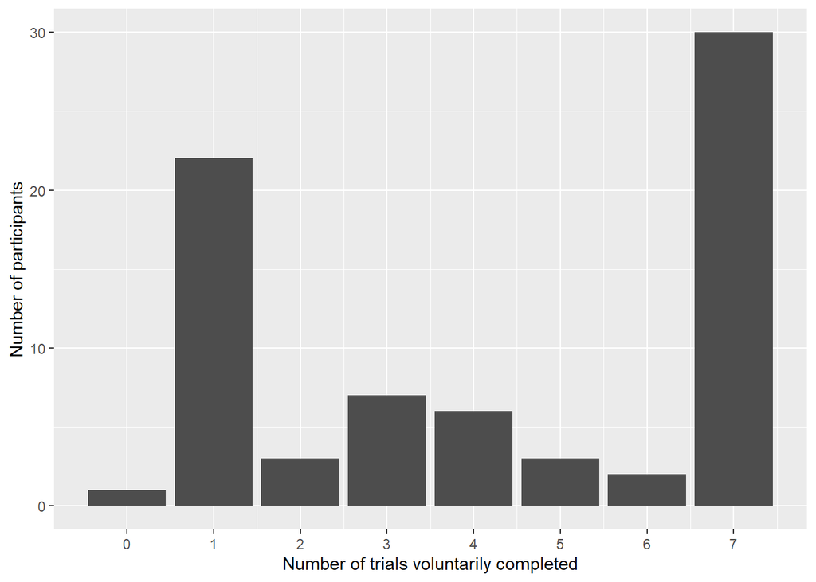

```r
dat %>%
  ggplot(aes(persist)) +
  geom_bar(fill = c) +
  ylab("Number of participants") +
  plot_trials
```

Yes, there is considerable variation in number of trials completed.

## Possible alternative explanations

Explanations for variation in persistence that are not interest in CS or the result of feeling greater expectancy-value from seeing a role model in the field.

- Chance
- Confounding variables
  - Model attractiveness
- Participant characteristics
  - GPA (conscientiousness)
  - Prior interest in CS
  - Age (worldly experience)
  - Year (senioritis ?)
  - Prior experience with CS
  - Major (perception of relevance & prior experience)
  - Perceptions of relevance & usefulness (utility beliefs)
  - Employment (time spent on CS, workplace experience factoring into utility beliefs)
  - Conscious stereotypes (descriptions of CS majors containing stereotypical language)
  - Unconscious stereotypes (reports of percentages of white and/or Asian CS majors)
- Participant background (other than race and gender)
  - We did not ask if students were first-generation or what degree their mother obtained (SES)
  - Parent(s)’ experience with CS (feeds into prior experience and perceptions)
  - Transfer status (SES)
  - Parental attitudes about gender (stereotype)
  - Parental attitudes about race (stereotype)
  - Friends’ attitudes about gender (stereotype)
  - Friends’ attitudes about race (stereotype)
  - Stereotypical beliefs

We can check for the above by controlling within the model OR by checking equal distribution among condition groups.

Note: find literature or a good reason to back up each potential alternative explanation !!

The fact that the distribution for trials completed is slightly bimodal makes me wonder whether the variation is simply due to general conscientiousness, with conscientious students always completing the lesson, but less conscientious students stopping after the first one. (Alternatively, it could just be a ceiling effect). We can plot persistence against GPA to gain more understanding of whether this is the case.

```r
dat %>%
  select(gpa,
         age,
         year,
         transfer,
         persist) %>%
  cormat()
```

```
##             gpa    age   year transfer persist
## gpa       1.000     NA     NA       NA      NA
## age      -0.131  1.000     NA       NA      NA
## year     -0.274  0.551  1.000       NA      NA
## transfer  0.002  0.570  0.536    1.000      NA
## persist   0.052 -0.187 -0.082   -0.198       1
```

GPA does not seem to be related to number of trials completed, so something other than general conscientiousness could be at play here. Of course, many factors other than conscientiousness play into GPA. Note: What’s something else we could use to measure this?

Let’s check whether any correlations seem to exist between time spent on the entire experiment, and prior attitudes towards computer science.

```r
dat %>%
  select(pre_att_act,
         pre_att_cs,
         post_att_cs,
         post_att_act,
         persist,
         dropoff) %>%
  cormat()
```

```
##              pre_att_act pre_att_cs post_att_cs post_att_act persist dropoff
## pre_att_act        1.000         NA          NA           NA      NA      NA
## pre_att_cs         0.410      1.000          NA           NA      NA      NA
## post_att_cs        0.338      0.716       1.000           NA      NA      NA
## post_att_act       0.436      0.487       0.697        1.000      NA      NA
## persist            0.133      0.105       0.298        0.433   1.000      NA
## dropoff           -0.171     -0.172      -0.306       -0.456  -0.826       1
```

There are only weak to moderate correlations here for the most part. However, it looks like pre-activity attitudes towards CS correlate with post-activity attitudes (people’s attitudes towards CS are fairly stable). Post-activity interest in the activity correlates more with post-activity attitudes towards CS than pre-activity attitudes, however, indicating that your experience during the activity may change your attitudes towards CS. I wonder what the breakdown is for people who were already interested before the activity and people who had no idea what to expect.

## Common-sense correlations between constructs

I also want to check the correlation between some variables that I would assume are related: predicted likelihood of taking CS courses, interest in CS, interest in the activity, belongingness in CS courses, etc.

```r
dat %>%
  select(matches("mom"),
         matches("dad"),
         matches("parent"),
         matches("friends")) %>%
  cormat()
```

```
##              mom_cs dad_cs parents_fem parents_race friends_fem friends_race
## mom_cs        1.000     NA          NA           NA          NA           NA
## dad_cs        0.478  1.000          NA           NA          NA           NA
## parents_fem   0.123  0.048       1.000           NA          NA           NA
## parents_race  0.198  0.112       0.398        1.000          NA           NA
## friends_fem   0.102 -0.029       0.711        0.489       1.000           NA
## friends_race  0.049  0.096       0.475        0.755       0.609        1.000
## friends_cs    0.242  0.295       0.125        0.125       0.152        0.059
##              friends_cs
## mom_cs               NA
## dad_cs               NA
## parents_fem          NA
## parents_race         NA
## friends_fem          NA
## friends_race         NA
## friends_cs            1
```

Only parents’ and friends’ stereotypical attitudes about race and feminism correlate highly enough to be composited. All other environmental variables appear to capture different constructs.

```r
dat %>%
  select(mom_cs, dad_cs, likely_cs_course, pre_att_cs) %>%
  cormat()
```

```
##                  mom_cs dad_cs likely_cs_course pre_att_cs
## mom_cs            1.000     NA               NA         NA
## dad_cs            0.478  1.000               NA         NA
## likely_cs_course  0.171  0.220            1.000         NA
## pre_att_cs       -0.020  0.137            0.624          1
```

I did not expect parental experience with CS to correlate so weakly with likelihood of taking a CS course or with CS attitudes, but this makes sense if we think about generational differences. Many more people are taking CS and thinking about CS now than in our parents’ generation, I think.

What is interesting about people who show increased interest in computer science? Does inclusion make people more interested in CS? This activity without manipulation leads people to be less interested in computer science. This is similar to the way we teach computer science normally. Go to online programming websites and screenshot.

*People are interested in CS, but don’t feel like they fit. Does this affect their likelihood of actually taking the course?* Extracurriculars and CS community?

```r
dat %>%
  select(fit_cs_class,
         likely_cs_course,
         pre_att_cs,
         pre_att_act,
         post_att_cs,
         post_att_act) %>%
  cormat()
```

```
##                  fit_cs_class likely_cs_course pre_att_cs pre_att_act
## fit_cs_class            1.000               NA         NA          NA
## likely_cs_course        0.186            1.000         NA          NA
## pre_att_cs              0.235            0.588      1.000          NA
## pre_att_act             0.082            0.146      0.410       1.000
## post_att_cs             0.213            0.698      0.716       0.338
## post_att_act            0.011            0.479      0.487       0.436
##                  post_att_cs post_att_act
## fit_cs_class              NA           NA
## likely_cs_course          NA           NA
## pre_att_cs                NA           NA
## pre_att_act               NA           NA
## post_att_cs            1.000           NA
## post_att_act           0.697            1
```

- maybe students’ likelihood of taking CS is dictated by their degree programs more than their interest
  - note after other analyses: it appears that transfer students do not have the time to take computer science courses
- or maybe this was a poorly constructed task that all students hated.

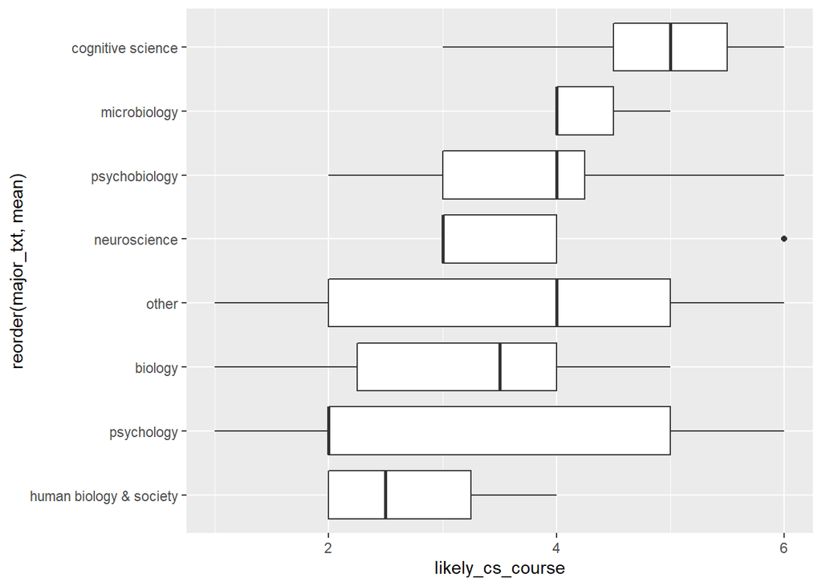

```r
dat %>%
  group_by(major_txt) %>%
  mutate(mean = mean(as.numeric(likely_cs_course), na.rm = TRUE)) %>%
  ungroup() %>%
  mutate(likely_cs_course = as.numeric(likely_cs_course))%>%
  ggplot(aes(likely_cs_course, reorder(major_txt, mean))) +
  geom_boxplot()
```

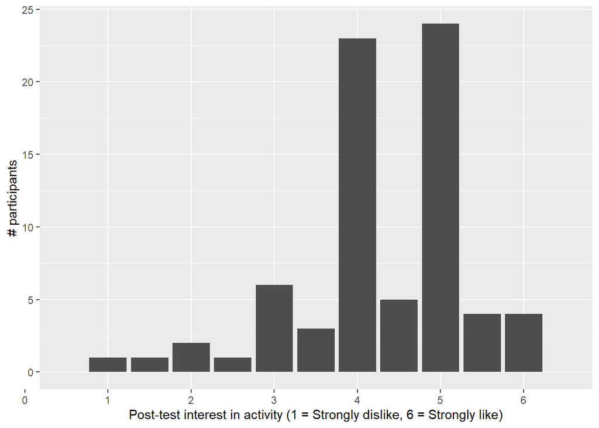

```r
dat %>%
  ggplot(aes(as.numeric(post_att_act))) +
  geom_bar(fill = c) +
  plot_post_interest +
  ylab("# participants")
```

Well, that disproves the second hypothesis (of floor effects), although acquiescence and demand characteristics are still possibilities.

I also realized that many students marked themselves as having taken a CS course in the past, which may invalidate half the data. We should conduct analyses with both groups and see if they differ.

```r
dat %>%
  select(cs_xp, post_att_act, persist, seconds, post_belonging, dropoff) %>%
  cormat()
```

```
##                 cs_xp post_att_act persist seconds post_belonging dropoff
## cs_xp           1.000           NA      NA      NA             NA      NA
## post_att_act    0.147        1.000      NA      NA             NA      NA
## persist         0.041        0.433   1.000      NA             NA      NA
## seconds        -0.118       -0.064   0.019   1.000             NA      NA
## post_belonging  0.236        0.462   0.407   0.033          1.000      NA
## dropoff         0.029       -0.456  -0.826  -0.157         -0.359       1
```

```r
wilcox.test(as.numeric(post_interest_act) ~ cs_xp, data = dat)
```

```
##
##  Wilcoxon rank sum test with continuity correction
##
## data:  as.numeric(post_interest_act) by cs_xp
## W = 659.5, p-value = 0.7789
## alternative hypothesis: true location shift is not equal to 0
```

Although there appears to be a shift where students who have taken CS courses before are more interested in the activity, the small sample size makes the difference not significant.

*Do people who show reduced interest in the activity also show reduced interest in computer science? (pre and post analysis)*

For students who didn’t have strong prior interest in CS, how did the activity change their interest in CS?

```r
dat %>%
  select(d_att_cs, d_att_act, pre_att_cs, pre_att_act, post_att_act) %>%
  cormat()
```

```
##              d_att_cs d_att_act pre_att_cs pre_att_act post_att_act
## d_att_cs        1.000        NA         NA          NA           NA
## d_att_act       0.364     1.000         NA          NA           NA
## pre_att_cs     -0.361     0.117      1.000          NA           NA
## pre_att_act    -0.089    -0.458      0.410       1.000           NA
## post_att_act    0.289     0.600      0.487       0.436            1
```

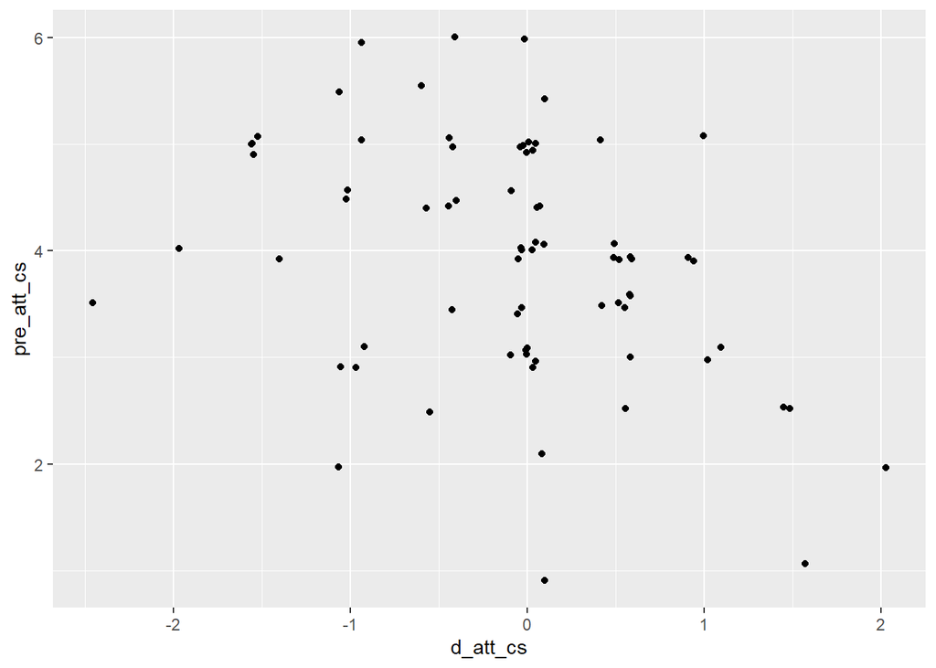

```r
dat %>%
  ggplot(aes(d_att_cs, pre_att_cs)) +
  jitter
```

There is a weak negative correlation between change in attitude and prior attitudes; people who had strong prior affinity did not change their attitude much, as expected. People with lower or moderate beliefs experienced some change, but the relation is not strong.

Trying to find explanatory factors for students’ attitudes towards CS.

```r
dat %>%
  select(pre_att_cs,
         post_att_cs,
         d_att_cs,
         post_difficult,
         post_opp_cost,
         post_belonging,
         post_stress,
         post_time_cost,
         matches("r_att"),
         matches("relative"),
         -matches("txt")) %>%
  cormat()
```

```
##                    pre_att_cs post_att_cs d_att_cs post_difficult post_opp_cost
## pre_att_cs              1.000          NA       NA             NA            NA
## post_att_cs             0.716       1.000       NA             NA            NA
## d_att_cs               -0.361       0.392    1.000             NA            NA
## post_difficult         -0.064      -0.050    0.017          1.000            NA
## post_opp_cost          -0.394      -0.392   -0.004          0.289         1.000
## post_belonging          0.471       0.599    0.179         -0.160        -0.567
## post_stress            -0.425      -0.366    0.071          0.485         0.727
## post_time_cost         -0.365      -0.312    0.063          0.320         0.636
## pre_r_att               0.570       0.566    0.006         -0.050        -0.440
## post_r_att              0.310       0.595    0.387         -0.053        -0.244
## relative_effort        -0.073      -0.077   -0.006          0.318         0.349
## relative_difficult     -0.185      -0.332   -0.200          0.329         0.366
## relative_school         0.091       0.182    0.123          0.405         0.078
##                    post_belonging post_stress post_time_cost pre_r_att
## pre_att_cs                     NA          NA             NA        NA
## post_att_cs                    NA          NA             NA        NA
## d_att_cs                       NA          NA             NA        NA
## post_difficult                 NA          NA             NA        NA
## post_opp_cost                  NA          NA             NA        NA
## post_belonging              1.000          NA             NA        NA
## post_stress                -0.414       1.000             NA        NA
## post_time_cost             -0.421       0.694          1.000        NA
## pre_r_att                   0.478      -0.332         -0.270     1.000
## post_r_att                  0.474      -0.129         -0.188     0.373
## relative_effort            -0.086       0.434          0.286    -0.016
## relative_difficult         -0.336       0.464          0.309    -0.259
## relative_school             0.063       0.323          0.138    -0.035
##                    post_r_att relative_effort relative_difficult
## pre_att_cs                 NA              NA                 NA
## post_att_cs                NA              NA                 NA
## d_att_cs                   NA              NA                 NA
## post_difficult             NA              NA                 NA
## post_opp_cost              NA              NA                 NA
## post_belonging             NA              NA                 NA
## post_stress                NA              NA                 NA
## post_time_cost             NA              NA                 NA
## pre_r_att                  NA              NA                 NA
## post_r_att              1.000              NA                 NA
## relative_effort         0.010           1.000                 NA
## relative_difficult     -0.414           0.305              1.000
## relative_school         0.050           0.304              0.329
##                    relative_school
## pre_att_cs                      NA
## post_att_cs                     NA
## d_att_cs                        NA
## post_difficult                  NA
## post_opp_cost                   NA
## post_belonging                  NA
## post_stress                     NA
## post_time_cost                  NA
## pre_r_att                       NA
## post_r_att                      NA
## relative_effort                 NA
## relative_difficult              NA
## relative_school                  1
```

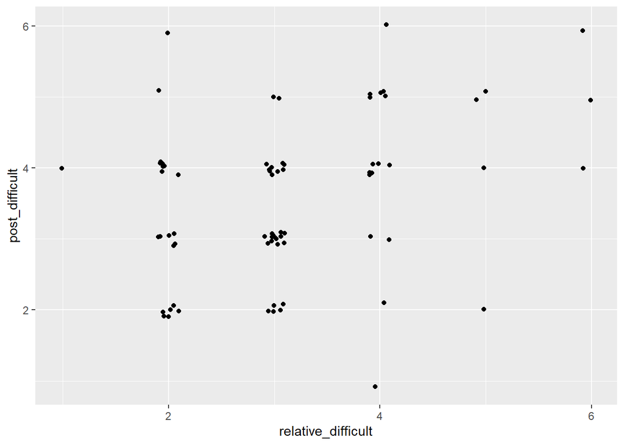

```r
dat %>%
  ggplot(aes(relative_difficult, post_difficult)) +
  jitter
```

```r
dat %>%
  select(matches("growth"), matches("fixed")) %>%
  cormat()
```

```
##             post_growth post_fixed1 post_fixed2 post_fixed3
## post_growth       1.000          NA          NA          NA
## post_fixed1      -0.020       1.000          NA          NA
## post_fixed2      -0.322       0.215       1.000          NA
## post_fixed3      -0.362       0.204       0.228           1
```

With the following graph, I can start to gain an understanding of how people view the distribution of computer scientists.

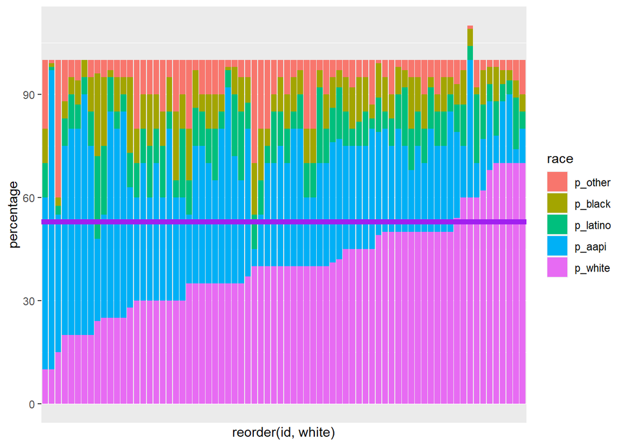

```r
dat %>%
  mutate(white = p_white) %>%
  pivot_longer(p_black:p_other,
               names_to = "race",
               values_to = "percentage") %>%
  ggplot() +
  geom_bar(aes(reorder(id, white),
               percentage,
               fill = fct_reorder(race, percentage)),
           stat = "identity",
           position = "stack") +
  scale_x_discrete(breaks = c(0, 100)) +
  geom_hline(yintercept = 52.9, color = "purple", size = 2) +
  guides(fill = guide_legend(title = "race"))
```

```r
sum(dat$p_aapi - 15.8) / 74
```

```
## [1] 17.32162
```

```r
sum(dat$p_black - 8.6) / 74
```

```
## [1] 0.1027027
```

```r
sum(dat$p_latino - 10.2) / 74
```

```
## [1] -0.2945946
```

```r
sum(dat$p_white - 52.9) / 74
```

```
## [1] -12.62973
```

Based on the information above, it seems that most people believe that white and Asian people constitute the majority of computer scientists.

From the [NCES website](https://nces.ed.gov/programs/digest/d19/tables/dt19_322.30.asp), I found the actual percentages of computer science undergraduates of each background from 2017-18. From calculating a simple distance, it seems like on average, participants were very good at guessing the actual percentages of Black and Latino computer scientists - and overestimated the percentage of Asian computer scientists. Looks like stereotypes have changed since earlier studies were conducted.

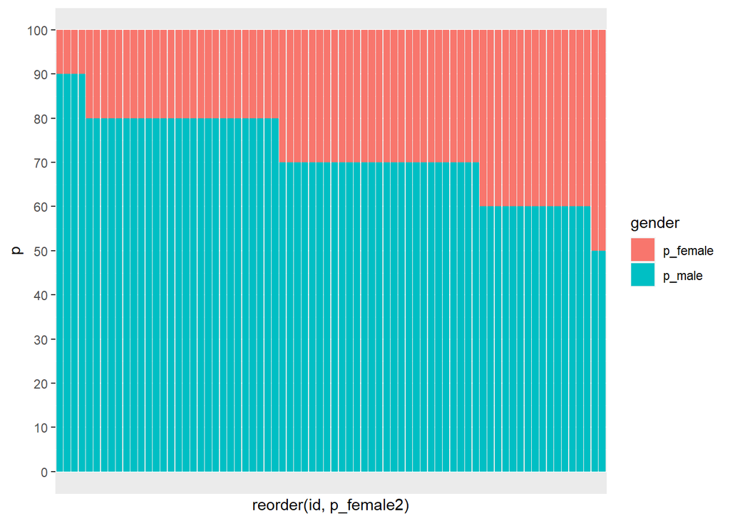

```r
dat %>%
  mutate(p_male = 100 - p_female,
         p_female2 = p_female) %>%
  pivot_longer(c("p_female", "p_male"), names_to = "gender", values_to = "p") %>%
  ggplot() +
  geom_bar(aes(reorder(id, p_female2), p, fill = gender),
           stat = "identity",
           position = "stack") +
  scale_x_discrete(breaks = c(0, 100)) +
  scale_y_continuous(n.breaks = 11)
```

~100% of participants believe that there are less females than males.

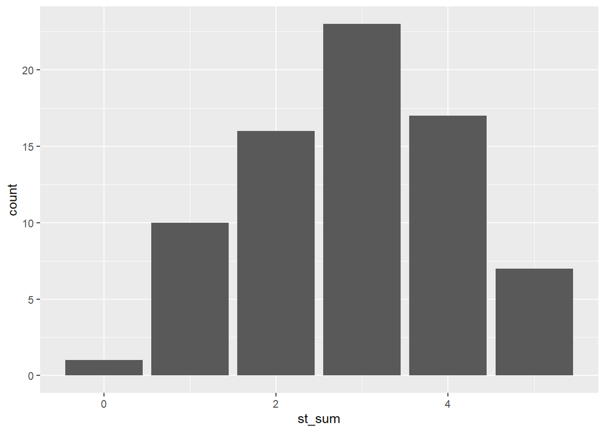

```r
dat %>%
  ggplot(aes(st_sum)) +
  geom_bar()
```

## Sources

[Correlation matrices](https://rstudio-pubs-static.s3.amazonaws.com/240657_5157ff98e8204c358b2118fa69162e18.html)